# 8 Posterior Prediction & Hypothesis Specification

Author

Johnny van Doorn

Published

June 15, 2026

By the end of this lecture, you will be able to:

- Derive and simulate the posterior predictive distribution
- Run a prior predictive check and a posterior predictive model check
- Explain how the choice of $H_1$ changes the Bayes factor (Jeffreys’s platitude)
- Compute and compare Bayes factors for different hypothesis specifications
- Describe why vague alternatives are penalised (Occam’s razor)

**Recommended Reading:** *Bayes Rules!* Chapter 8; Etz, Haaf, Rouder & Vandekerckhove (2018). Bayesian inference and testing any hypothesis you can specify. *Advances in Methods and Practices in Psychological Science*. doi: 10.1177/2515245918773087

# Posterior Prediction

## Two Uses of Prediction

|  | Question | Timing |
| --- | --- | --- |
| **Prior predictive** | What does my model predict *before* data? | Before data |
| **Posterior predictive** | What new data should I expect *after* updating? | After updating |

Both simulate *data* (not parameters), and serve different purposes.

## Prior Predictive Check

Simulate data from the prior to check whether the prior encodes scientifically plausible values.

**Algorithm**

1. Draw $\theta^{(i)}$ from the prior $f(\theta)$
2. Simulate $y^{(i)}$ from the likelihood $f(y \mid \theta^{(i)})$
3. Plot $\{y^{(i)}\}$: if it implies impossible or absurd observations, revise the prior

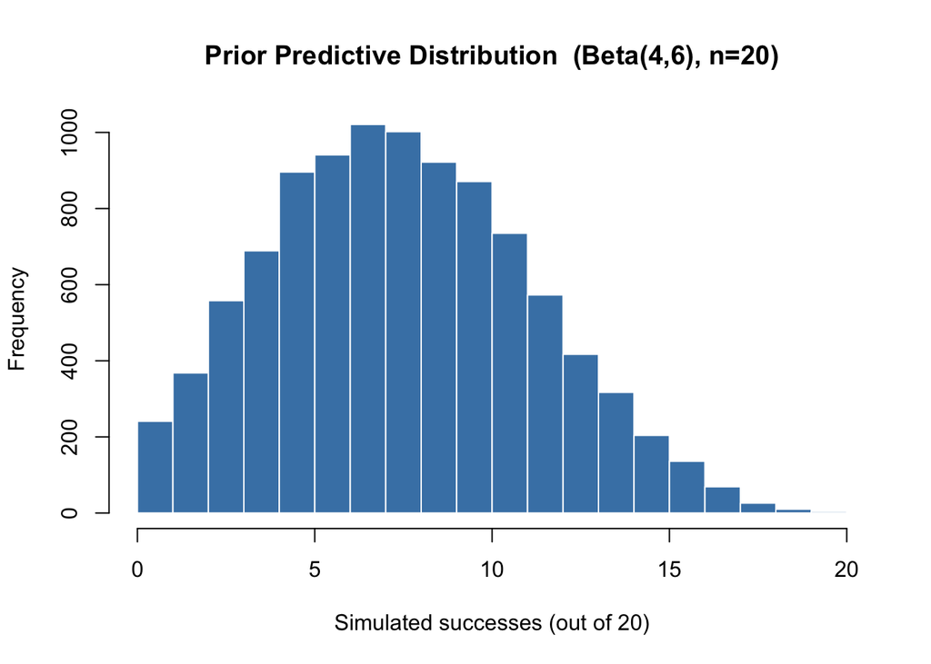

```r
# Prior: Beta(4, 6);  planning n = 20
theta_prior  <- rbeta(1e4, shape1 = 4, shape2 = 6)
y_prior_pred <- rbinom(1e4, size = 20, prob = theta_prior)

hist(y_prior_pred, breaks = 0:20, probability = FALSE,
     main = "Prior Predictive Distribution  (Beta(4,6), n=20)",
     xlab = "Simulated successes (out of 20)",
     col = "steelblue", border = "white")
```

**Interpretation:** The prior predicts mostly 4–12 successes out of 20, centred around 8 (40%). This looks plausible for a proportion expected to be around 40% (since $\mathbb{E}[\pi] = 4/10 = 0.4$).

## The Posterior Predictive Distribution

After updating on $y$, we want to predict $Y'$ for a new observation:

$$f(y' \mid y) = \int f(y' \mid \theta)\, f(\theta \mid y)\, d\theta$$

This marginalises over **two sources of uncertainty**:

- **Parameter uncertainty**: we don’t know $\theta$ exactly → integrate over the posterior
- **Sampling variability**: even if $\theta$ were known, new observations vary around it

**Simulation algorithm**

1. Draw $\theta^{(i)}$ from the posterior $f(\theta \mid y)$
2. Simulate $Y'^{(i)}$ from the likelihood at each $\theta^{(i)}$
3. $\{Y'^{(i)}\}$ approximates the posterior predictive distribution

```r
# Posterior: Beta(18, 92);  predict for n = 20 new cases
theta_post  <- rbeta(1e4, 18, 92)
y_post_pred <- rbinom(1e4, size = 20, prob = theta_post)

cat("E(Y' | y):", round(mean(y_post_pred), 2), "\n")
```

```
E(Y' | y): 3.28
```

```r
cat("P(Y' >= 5 | y):", round(mean(y_post_pred >= 5), 3), "\n")
```

```
P(Y' >= 5 | y): 0.238
```

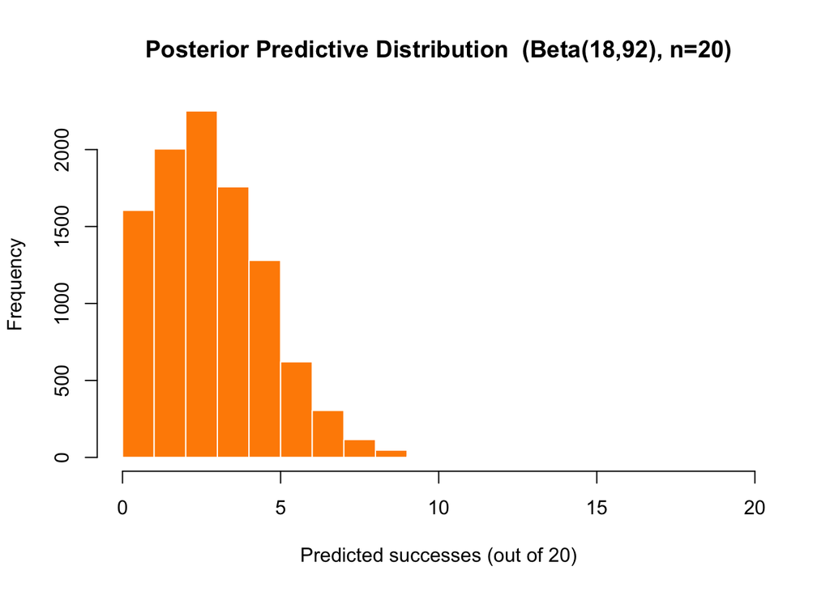

```r
hist(y_post_pred, breaks = 0:20, probability = FALSE,
     main = "Posterior Predictive Distribution  (Beta(18,92), n=20)",
     xlab = "Predicted successes (out of 20)",
     col = "darkorange", border = "white")
```

## Posterior Predictive Model Check

Simulate replicated datasets $y^\text{rep}$ under the fitted model and compare them to the observed data $y_\text{obs}$. This is a Bayesian analogue of a goodness-of-fit test.

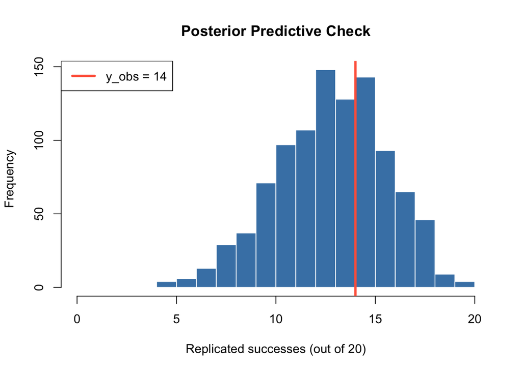

```r
# Original data: n = 20, y_obs = 14;  Posterior: Beta(18, 9)
theta_rep <- rbeta(1e3, 18, 9)
y_rep     <- rbinom(1e3, size = 20, prob = theta_rep)

hist(y_rep, breaks = 0:20, probability = FALSE,
     main = "Posterior Predictive Check",
     xlab = "Replicated successes (out of 20)",
     col  = "steelblue", border = "white")
abline(v = 14, col = "tomato", lwd = 3)
legend("topleft", legend = "y_obs = 14", col = "tomato", lwd = 3)
```

```r
# Posterior predictive p-value
pp_pval <- mean(y_rep >= 14)
cat("Posterior predictive p-value:", round(pp_pval, 3), "\n")
```

```
Posterior predictive p-value: 0.488
```

A posterior predictive p-value (pp p-value) near 0.5 indicates good model fit — the observed data fall near the centre of the replicated distribution. Values close to 0 or 1 suggest the model is systematically missing something.

# Hypothesis Testing: Specifying the Question

## Testing = Model Comparison

The Bayes factor compares how well two **fully specified** models predicted the data:

$$BF_{10} = \frac{P(y \mid \mathcal{H}_1)}{P(y \mid \mathcal{H}_0)}$$

where $P(y \mid \mathcal{H}) = \int f(y \mid \theta)\, f(\theta \mid \mathcal{H})\, d\theta$ is the **marginal likelihood** — the average predictive accuracy of the model.

**Jeffreys’s Platitude** (Etz et al., 2018)

“The answer depends on the question.” Slightly different hypothesis specifications can lead to different Bayes factors — sometimes qualitatively different conclusions. The null is always $H_0: \theta = \theta_0$; but there are many possible $H_1$s.

## The Running Example: Extrasensory Perception

> In a guessing task with 25 trials, a participant gets 15 correct.

The null is clear: $H_0: \theta = 0.5$ (performance at chance). But what should $H_1$ say?

| Alternative | Prior on $\theta$ | What it says |
| --- | --- | --- |
| One-sided ($H_+$) | $U(0.5, 1)$ | Any above-chance level is equally plausible |
| Slab ($H_S$) | $U(0, 1)$ | Completely agnostic |
| Specific point ($H_A$) | spike at 0.53 | A precise ESP-induced advantage |
| Negligible-effect ($H_N$) | $U(0.47, 0.53)$ | Any real effect is negligibly small |

## Computing the BFs

```r
y_obs <- 15; n_obs <- 25

# H_0: theta = 0.5
p_H0 <- dbinom(y_obs, n_obs, prob = 0.5)

# H_+: theta ~ U(0.5, 1)  (one-sided)
theta_plus <- seq(0.5, 1, length.out = 1e4)
p_Hplus    <- mean(dbinom(y_obs, n_obs, prob = theta_plus))
BF_plus0   <- p_Hplus / p_H0

# H_S: theta ~ U(0, 1)  (slab)
theta_slab <- seq(0, 1, length.out = 1e4)
p_HS       <- mean(dbinom(y_obs, n_obs, prob = theta_slab))
BF_S0      <- p_HS / p_H0

# H_A: theta = 0.53  (specific point)
p_HA  <- dbinom(y_obs, n_obs, prob = 0.53)
BF_A0 <- p_HA / p_H0

# H_N: theta ~ U(0.47, 0.53)  (negligible)
theta_neg <- seq(0.47, 0.53, length.out = 1e4)
p_HN      <- mean(dbinom(y_obs, n_obs, prob = theta_neg))
# H_Nbar: complement
theta_Nb  <- c(seq(0, 0.47, length.out = 5e3),
               seq(0.53, 1, length.out = 5e3))
p_HNb     <- mean(dbinom(y_obs, n_obs, prob = theta_Nb))
BF_N_Nb   <- p_HN / p_HNb

cat("BF(+, 0)  =", round(BF_plus0, 3), "— one-sided vs chance\n")
```

```
BF(+, 0)  = 0.661 — one-sided vs chance
```

```r
cat("BF(S, 0)  =", round(BF_S0,    3), "— slab vs chance\n")
```

```
BF(S, 0)  = 0.395 — slab vs chance
```

```r
cat("BF(A, 0)  =", round(BF_A0,    3), "— spike 0.53 vs chance\n")
```

```
BF(A, 0)  = 1.291 — spike 0.53 vs chance
```

```r
cat("BF(N, Nb) =", round(BF_N_Nb,  3), "— negligible vs non-negligible\n")
```

```
BF(N, Nb) = 2.807 — negligible vs non-negligible
```

## The Same Data, Different Answers

[output not shown]

*Table following Etz et al. (2018). Same 15/25 data — very different answers depending on the question asked.*

## Occam’s Razor: Why Vague Alternatives Are Penalised

**Occam’s razor in Bayes factor testing**

A model that spreads probability thinly over many outcomes makes weak predictions everywhere. It is automatically penalised relative to a more specific model — even if the data are consistent with it.

The slab $H_S: \theta \sim U(0,1)$ assigns equal probability to a success rate of 0.01 and 0.99. Because it must “cover everything,” it predicts 15/25 weakly — less strongly than $H_0: \theta = 0.5$ does. Result: $BF_{S0} < 1$ even though 15/25 is slightly above chance.

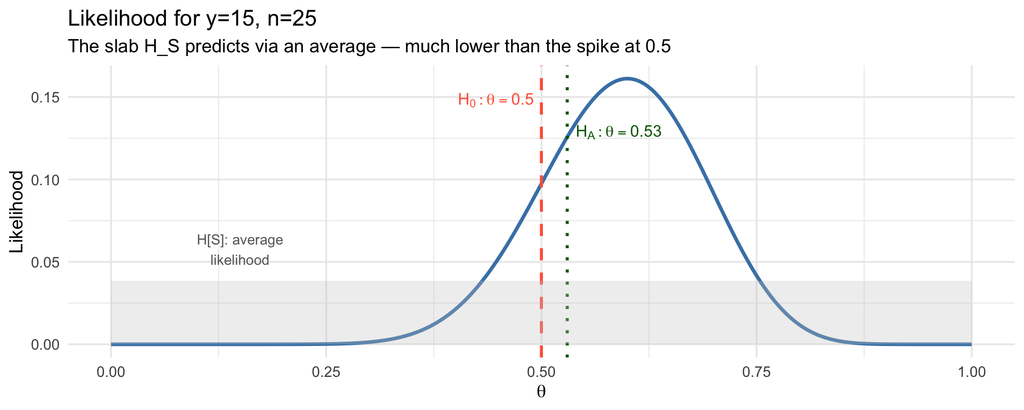

```r
theta_vals <- seq(0, 1, length.out = 500)
lik_vals   <- dbinom(15, 25, prob = theta_vals)

df_binom <- data.frame(theta = theta_vals, likelihood = lik_vals)

ggplot(df_binom, aes(x = theta, y = likelihood)) +
  geom_line(linewidth = 1.2, color = "steelblue") +
  geom_vline(xintercept = 0.5,  linetype = "dashed", color = "tomato",   linewidth = 1) +
  geom_vline(xintercept = 0.53, linetype = "dotted", color = "darkgreen",linewidth = 1) +
  annotate("text", x = 0.50, y = max(lik_vals) * 0.92,
           label = "H[0]: theta==0.5", parse = TRUE, color = "tomato", hjust = 1.1, size = 4) +
  annotate("text", x = 0.53, y = max(lik_vals) * 0.8,
           label = "H[A]: theta==0.53", parse = TRUE, color = "darkgreen", hjust = -0.1, size = 4) +
  annotate("rect", xmin = 0, xmax = 1, ymin = 0, ymax = mean(lik_vals),
           fill = "grey80", alpha = 0.3) +
  annotate("text", x = 0.15, y = mean(lik_vals) * 1.5,
           label = "H[S]: average\nlikelihood", color = "grey40", size = 3.5) +
  labs(title = "Likelihood for y=15, n=25",
       subtitle = "The slab H_S predicts via an average — much lower than the spike at 0.5",
       x = expression(theta), y = "Likelihood") +
  theme_minimal(base_size = 13)
```

**Implication for researchers:** think carefully about what your $H_1$ actually predicts. A vague “something is going on” hypothesis is not a strong scientific claim and will be penalised by the BF.

# In-Class Exercises

## Exercise 1: Posterior Prediction (CBT App)

> A researcher used the CBT app dataset with posterior Beta(26, 14) to predict outcomes in a new study of $n = 30$.

**Exercise**

1. Simulate 10,000 predictions for $Y'$.
2. Estimate $E(Y' \mid y)$ and $P(Y' \geq 20 \mid y)$.
3. Run a posterior predictive check on the original $y_\text{obs} = 14$ ($n = 20$). Is the model well-calibrated?

**Solution**

```r
set.seed(42)

# 1. Simulate posterior predictive for n = 30
theta_post  <- rbeta(1e4, 26, 14)
y_pred_30   <- rbinom(1e4, size = 30, prob = theta_post)

# 2. Summaries
cat("E(Y' | y) =", round(mean(y_pred_30), 2), "\n")
```

```
E(Y' | y) = 19.49
```

```r
cat("P(Y' >= 20 | y) =", round(mean(y_pred_30 >= 20), 3), "\n")
```

```
P(Y' >= 20 | y) = 0.517
```

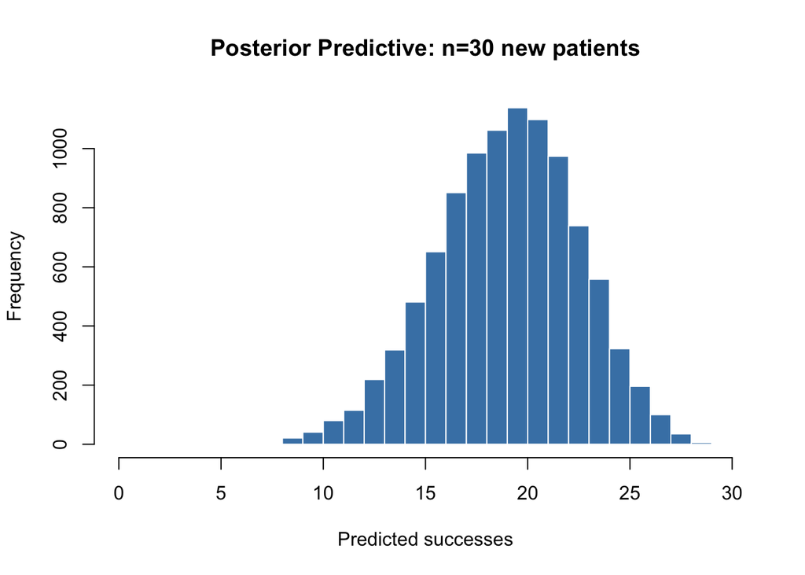

```r
hist(y_pred_30, breaks = 0:30, probability = FALSE,
     main = "Posterior Predictive: n=30 new patients",
     xlab = "Predicted successes", col = "steelblue", border = "white")
```

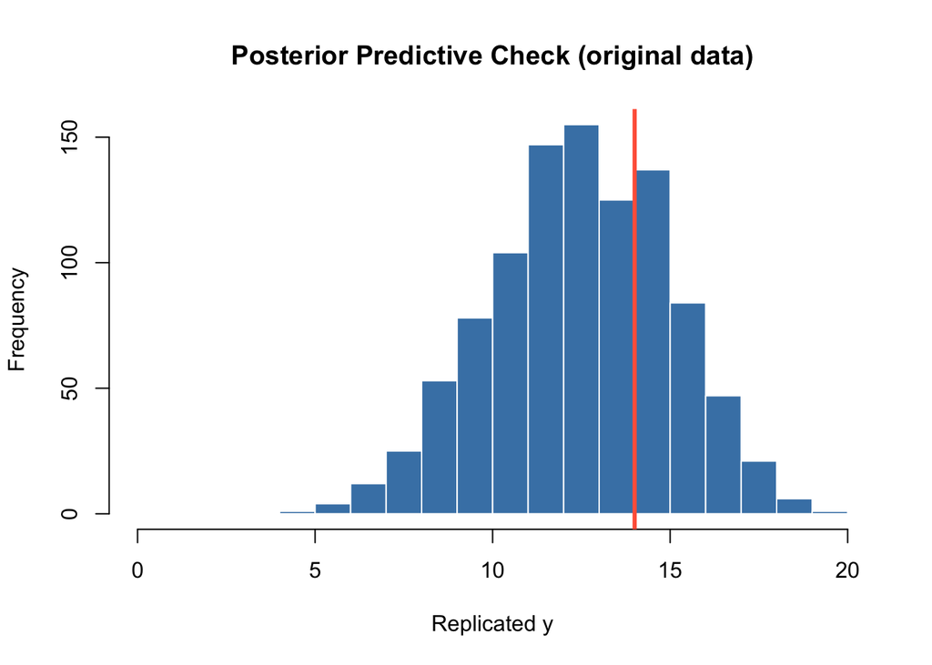

```r
# 3. PPC for original data (n = 20, y_obs = 14)
theta_rep2  <- rbeta(1e3, 26, 14)
y_rep2      <- rbinom(1e3, size = 20, prob = theta_rep2)

hist(y_rep2, breaks = 0:20,
     main = "Posterior Predictive Check (original data)",
     xlab = "Replicated y", col = "steelblue", border = "white")
abline(v = 14, col = "tomato", lwd = 3)
```

```r
pp_pval <- mean(y_rep2 >= 14)
cat("PP p-value:", round(pp_pval, 3), "\n")
```

```
PP p-value: 0.421
```

**Interpretation:** A pp p-value near 0.5 means $y_\text{obs} = 14$ falls close to the centre of the replicated distribution — good model fit.

## Exercise 2: Hypothesis Specification

> You test whether a new memory strategy improves recall above 50%. In 30 trials, 20 are correct.

**Exercise**

For each hypothesis below, compute the BF:

1. $H_0: \theta = 0.5$ vs. $H_+: \theta \sim U(0.5, 1)$
2. $H_0: \theta = 0.5$ vs. $H_S: \theta \sim U(0, 1)$
3. $H_0: \theta = 0.5$ vs. $H_A: \theta = 0.65$ (specific prediction from a theory)
4. How do the three BFs compare? What does this tell you about hypothesis specification?

**Solution**

```r
y2 <- 20; n2 <- 30
p0 <- dbinom(y2, n2, 0.5)

# 1. One-sided
theta_p <- seq(0.5, 1, length.out = 1e4)
BF_plus <- mean(dbinom(y2, n2, theta_p)) / p0

# 2. Slab
theta_s <- seq(0, 1, length.out = 1e4)
BF_slab <- mean(dbinom(y2, n2, theta_s)) / p0

# 3. Point alternative
BF_A <- dbinom(y2, n2, 0.65) / p0

cat("BF(+, 0)  =", round(BF_plus, 3), "— one-sided\n")
```

```
BF(+, 0)  = 2.224 — one-sided
```

```r
cat("BF(S, 0)  =", round(BF_slab, 3), "— slab\n")
```

```
BF(S, 0)  = 1.153 — slab
```

```r
cat("BF(A, 0)  =", round(BF_A,    3), "— point 0.65\n")
```

```
BF(A, 0)  = 5.368 — point 0.65
```

## Exercise 3: Prior Predictive Check for a Gamma–Poisson Model

> A researcher models daily number of panic attacks. They propose $\lambda \sim \text{Gamma}(2, 1)$ as a prior. Patients will be monitored for $n = 14$ days.

**Exercise**

1. Run a prior predictive check — simulate 14-day totals under this prior.
2. Is the prior plausible? What does it predict about the maximum daily count?
3. Suggest a revised prior and show how the predictive distribution changes.

**Solution**

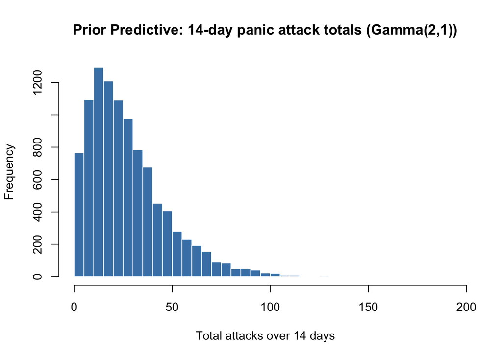

```r
set.seed(123)

# Prior: Gamma(2, 1), mean = 2 attacks/day
lambda_prior <- rgamma(1e4, shape = 2, rate = 1)

# Simulate 14-day totals
y_total <- rpois(1e4, lambda = lambda_prior * 14)   # sum of 14 Poisson draws

hist(y_total, breaks = 50,
     main = "Prior Predictive: 14-day panic attack totals (Gamma(2,1))",
     xlab = "Total attacks over 14 days", col = "steelblue", border = "white")
```

```r
cat("Prior predictive mean total:", round(mean(y_total), 1), "\n")
```

```
Prior predictive mean total: 27.7
```

```r
cat("P(total > 100):", round(mean(y_total > 100), 3), "\n")
```

```
P(total > 100): 0.006
```

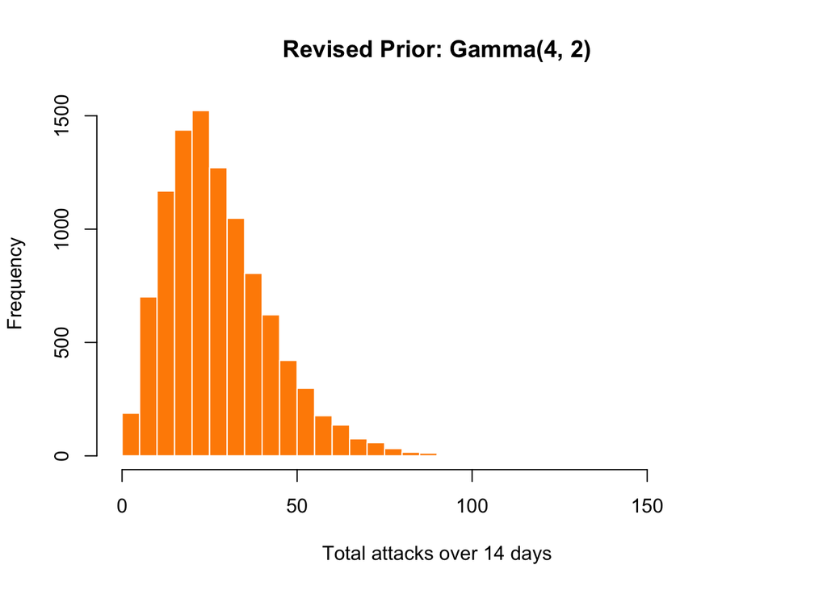

```r
# Revised: more informative prior, e.g. Gamma(4, 2), mean still = 2 but tighter
lambda_rev <- rgamma(1e4, shape = 4, rate = 2)
y_total_rev <- rpois(1e4, lambda = lambda_rev * 14)

hist(y_total_rev, breaks = 50, add = FALSE,
     main = "Revised Prior: Gamma(4, 2)",
     xlab = "Total attacks over 14 days", col = "darkorange", border = "white")
```

```r
cat("Revised P(total > 100):", round(mean(y_total_rev > 100), 3), "\n")
```

```
Revised P(total > 100): 0.001
```

**Next lecture (June 17):** Reporting guidelines (van Doorn et al. 2021), common mistakes, and mock exam preparation.